# Instructions

This exam is **untimed** and will be due on Wednesday April 10th. You **do not** have to complete this exam in one contiguous block of time; feel free to stop and start as you please, but ensure that you do not come in contact with disallowed resources in between sessions. While taking this exam, you are allowed to use:

- your book(s)
- your notes
- your previous codes from this class
- your completed code lessons
- lecture slides

and you **are not allowed to use**:

- the internet (if you need to look up python documentation, that's fine)
- another person
- another person's work

## Questions

### Question 1: (10 pts)

In chapter 8 we used the Ising model to study magnetism and phase transition. Explain what a phase transition is and how you can identify the temperature at which one occurs.

### Answer to Question 1

From a basic interpretation, a phase transition is the process of a state change for some material such as solid $\rightarrow$ liquid, liquid $\rightarrow$ to gas, etc. From a newer level of understanding from reviewing ideas and concepts from Statistical Mechanics, a phase transition has a lot to say about the orientations of physically characterized parameters such as electron spin. One of the key ideas of phase transition is that the orientation of spin (and hence its magnetic influence) in regions around it influence how the other spin states are also oriented. The Ising Model in conjunction with Monte-Carlo methods allows for a statistically accurate view of how these phenomena can be characterized by temperature changes in the system. And hence, this would attempt to describe the phase transition phenomena by use of statistical mechanics and random methods.

### Question 2 (10 pts)

In chapter 9 we studied Molecular Dynamics and modeled large systems by looking at small regions with wrap around boundary conditions, intitializing particles in a lattice and allowing them to interact. How would you set up a study using this type of system to study melting transitions by effectively changing the temperature (also address how you can change the temperature without causing changes in position that could lead to instabilities)?

### Answer to Question 2

When we used methods for modelling large systems such as Molecular Dynamics, it was helpful to incorporate a factor which was a function of temperature which would increase or decrease the velocity influence on the individual particles. This effectively put a buffer on the instability which would have otherwise been introduced by freely flowing particles. In that case, we would have expected that a small instability could lead to the whole system of particles moving together (after a sufficient amount of time) in a very VERY fast flowing 'fluid-like' state. For understanding the melting phase transition, we would expect that at some certain critical melting temperature $T_{\text{crit}}$ that the cluster of interacting 'molecules' would transform from a rigid form (where every particle had a relative region to stay within) to a form of higher flexibiility (where positions of particles are not necessarily bound to any one region). Like I said before, putting some buffer variable (as a function of temperature) as a coefficient to limit the incrementing position parameters would allow for retainment of stability while still maintaining valid characterization of when the phase transition is supposed to occur.

### Question 3 (30 pts)

In chapter 8 we used the Ising model to study the two-state paramagnet. Modify your code from that chapter to model a three-state paramagnet (also called the Potts model). Whereas in the Ising model the allowed site states were $s_i = \pm 1$, in the Potts model they are $s_i = +1, -1, 0$. Below you'll find some tips/hints:

1. The site energy for this system is similar, though not identical, to what it was for the two-state system. The interaction energy for the Potts model is given by: $$ H_i = -J \sum_j \delta(s_i,s_j)$$ where $\delta(s_i,s_j)$ is the Kronecker delta, which equals one whenever $s_i = s_j$ and zero otherwise. In other words, if neighboring spins are alike, their contribution to the total energy is $-J$, and if they are unlike, their contribution is 0.
2. Previously, you selected a random site and considered whether to "flip" the spin on that site. Now you're going to have to 1) randomly select a site for flipping and then 2) randomly select a new spin value from the other two possibilities. (Conversely, you could go through each element in your matrix then randomly select a new spin value)
3. Reproduce the plots similar to 8.7, 8.8 and 8.9 that you saw/did in your original chapter 8 problem showing the magnetization and specific heat per spin as functions of temperature with no background magnetic field. (but do this for the Potts model)

```python
# Ising Model using the algorithm depicted above
import numpy as np
from random import random, randint, choice
import matplotlib.pyplot as plt

class PottsModel:
    def __init__(self, N : int, J : float = 1.0):
        self.N = N
        self.J = J
        self.choices = [- 1.0, 0.0, 1.0]
        self.lattice = np.zeros((N + 2, N + 2))
        self.FillLattice()
        self.kB = 1
        # Parameters for the characterization of the overall lattice
        self.EVariance = 0.0
        self.E = 0.0
        self.M = 0.0

    def FillLattice(self):
        """Randomly fills the lattice with 75% spin up

        Returns:
            None
        """
        # Assigns random spin states to the lattice points on the grid
        for i in range(1, self.N + 1):
            for j in range(1, self.N + 1):
                self.lattice[i][j] = choice(self.choices)

        return None

    def UpdateParameters(self):
        """Simply updates the total magetic moment and energy of the lattice into private variables

        Returns:
            None
        """
        # Reset the Energy and variance to 0
        self.E = 0.0
        self.EVariance = 0.0

        # Compute the magnetic moment by adding the spins on the lattice
        self.M = np.sum(self.lattice)

        for i in range(1, self.N + 1):
            for j in range(1, self.N + 1):
                # Calculate the energy by entering the ij component into the KroneckerDelta function with its neighbor and sum over the 4 neighbor contributions
                self.E += - self.J * (self.KroneckerDelta(self.lattice[i, j], self.lattice[i - 1, j]) + self.KroneckerDelta(self.lattice[i, j], self.lattice[i, j - 1]) \
                    + self.KroneckerDelta(self.lattice[i, j], self.lattice[i + 1, j]) + self.KroneckerDelta(self.lattice[i, j], self.lattice[i, j + 1]))

        for i in range(1, self.N + 1):
            for j in range(1, self.N + 1):
                # Calculate the energy once again, but take the difference from the mean, and square it. This adds to the variance term.
                self.EVariance += (- self.J * (self.KroneckerDelta(self.lattice[i, j], self.lattice[i - 1, j]) + self.KroneckerDelta(self.lattice[i, j], self.lattice[i, j - 1]) \
                    + self.KroneckerDelta(self.lattice[i, j], self.lattice[i + 1, j]) + self.KroneckerDelta(self.lattice[i, j], self.lattice[i, j + 1]))) ** 2

        # Compute and store the variance by dividing by n (sample size) - 1
        self.EVariance /= (self.N * self.N - 1)

        return None

    def KroneckerDelta(self, s1, s2):
        return 1 if s1 == s2 else 0

    def MetropolisAlgorithm(self, T : float):
        """Randomly picks a point in the lattice to update its value to spin up or down depending on its energy with its nearest neighbors

        Args:
            T (float): temperature under evaluation

        Returns:
            None
        """
        # Choose a random point on the lattice to evaluate
        i, j = randint(1, self.N), randint(1, self.N)

        # Calculate the energy of that state with the Kronecker delta to compare the spin states
        E = - self.J * (self.KroneckerDelta(self.lattice[i, j], self.lattice[i - 1, j]) + self.KroneckerDelta(self.lattice[i, j], self.lattice[i, j - 1]) \
            + self.KroneckerDelta(self.lattice[i, j], self.lattice[i + 1, j]) + self.KroneckerDelta(self.lattice[i, j], self.lattice[i, j + 1]))

        # temporarily make a list element with all options except for the one at the ij index
        options = [o for o in self.choices if o != self.lattice[i, j]]

        # Since the energy to flip the state is the negative of its current energy, I simply reverse the directions of inequalities which I stated above
        if E >= 0:
            # randomly choose from the other 2 spin states available if the energy can be lowered
            self.lattice[i, j] = choice(options)
        elif random() < np.exp(E / (self.kB * T)):
            # if the energy was already low but we randomly want to flip the state, we randomly choose from another spin state option
            self.lattice[i, j] = choice(options)
        else:
            # otherwise, and as expected if the energy was already minimized, nothing should change at the ij grid point
            pass

        self.UpdateParameters()
        return None

    def Animate(self, nIters : int, T : float):
        """Animates the Ising model nIters number of times for temp T

        Args:
            nIters (int): number of times to iterate the model
            T (float): temperature evaluated
        """
        for _ in range(nIters):
            self.MetropolisAlgorithm(T = T)
            plt.imshow(self.lattice[1 : -1, 1 : -1], cmap = 'cool')
            plt.draw()
            plt.pause(0.00001)
            plt.clf()

        plt.close()
        return

    def ParametersVsTemp(self, TMin : float, TMax : float, nPoints : int, nIters : int):
        """Gets the lists and arrays necessary to plot energy and magnetization vs temperature

        Args:
            TMin (float): min temp test to test
            TMax (float): max temp value to test
            nPoints (int): number of temperature points to test in between max and min
            nIters (int): number of Monte-Carlo time steps (the more, the better for accuracy)

        Returns:
            TempArray, EnergyArray, EnergyVarianceArray, MagnetizationArray: arrays for plotting
        """

        # Make the arrays and lists to plot against once computation is ended
        T = np.linspace(TMin, TMax, nPoints)
        E = []
        EVariance = []
        M = []

        for t in T:
            # Reset the lattice for a new temperature to test
            self.FillLattice()

            # I create little parameters e, eV, and m to sum over the values to approximate an average of energy, variance, and magnetization
            e = 0.0
            eV = 0.0
            m = 0.0
            for _ in range(nIters):
                self.MetropolisAlgorithm(T = t)

                # Only start accumulating the average if it has been iterated at least 1000 times
                if _ > 1000:
                    # The energy is saved as the sum of the entire lattice, but we only plot the mean
                    e += self.E / (self.N * self.N)
                    eV += self.EVariance
                    # Likewise with M, we only plot the mean
                    m += self.M / (self.N * self.N)

            # After running the algorithm nIters number of times, save the energy, variance, and magnetization averages
            E.append(e / (nIters - 1000))
            EVariance.append(eV / (nIters - 1000))
            M.append(m / (nIters - 1000))

        return T, E, EVariance, M

# Instantiate the lattice class
latticeStructure = PottsModel(N = 10, J = 1)
```

```python
%matplotlib osx
latticeStructure.Animate(nIters = 1000, T = 1.5)
```

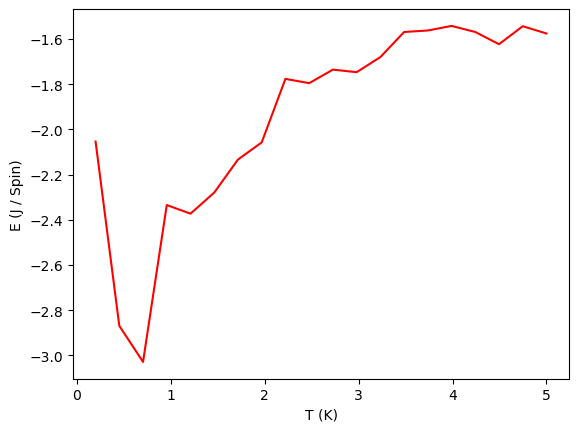

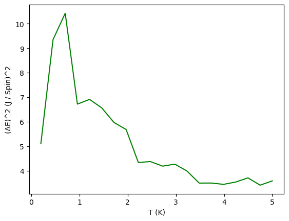

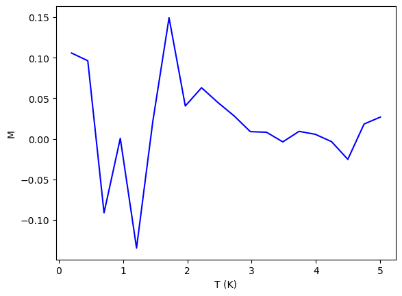

```python
%matplotlib inline
# Compute all of the parameters of the model given a temp range of 0.25 K to 5.0 K with 20 data points and 3000 Monte-Carlo time steps
T, E, EVariance, M = latticeStructure.ParametersVsTemp(TMin = 0.2, TMax = 5.0, nPoints = 20, nIters = 3000)

# Plot average energy
plt.xlabel('T (K)')
plt.ylabel('E (J / Spin)')
plt.plot(T, E, 'r-')
plt.show()

# Plot energy variance
plt.xlabel('T (K)')
plt.ylabel('(ΔE)^2 (J / Spin)^2')
plt.plot(T, EVariance, 'g-')
plt.show()

# Plot magentization mean
plt.xlabel('T (K)')
plt.ylabel('M')
plt.plot(T, M, 'b-')
plt.show()
```

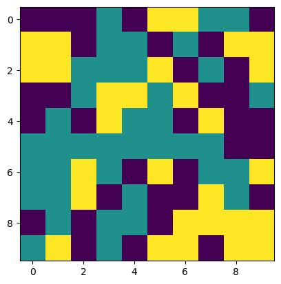

```python
%matplotlib inline
# And to show the results of the algorithm for PDF Format to display
# This is the lattice at T = 5.0 K after 3000 Monte-Carlo time steps
plt.imshow(latticeStructure.lattice[1 : -1, 1 : -1])
plt.show()
```

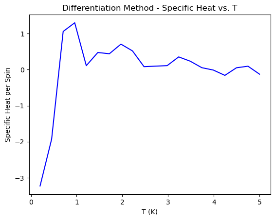

```python
%matplotlib inline
# Method 1 - Differentiation

# Convert Energy and Variance to an array instead of a list
E = np.array(E)
EVariance = np.array(EVariance)
dT = T[1] - T[0] # All dTs are constant
# And then make a space to save the specific heat
C = []

# Save the first derivative using forward difference method
C.append((E[1] - E[0]) / dT)

for i in range(1, len(T) - 1):
    # Center difference method for middle points of the grid
    C.append((E[i + 1] - E[i - 1]) / (2 * dT))

# And finally, save the last derivative using backward difference method
C.append((E[-1] - E[-2]) / dT)

"""
Since E is already in the form of an expected value, or the average of the energy per spin, it can be
directly substituted into equation (3), which is exactly what I have done. Now, to plot!
"""

plt.plot(T, C, 'b-')
plt.title('Differentiation Method - Specific Heat vs. T')
plt.xlabel('T (K)')
plt.ylabel('Specific Heat per Spin')
plt.show()
```

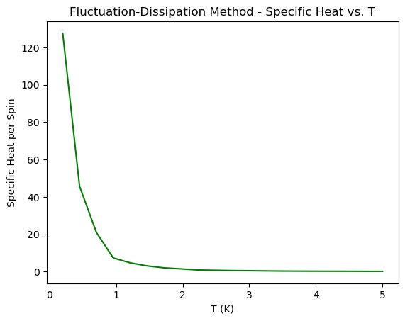

```python
%matplotlib inline
# Method 2 - Fluctuation-Dissipation

"""
A new C value will be found by making use of the variance of E as with equation (4), as opposed to differentiating E vs T.
"""

C = np.array([eV / t ** 2 for eV, t in zip(EVariance, T)])

plt.plot(T, C, 'g-')
plt.title('Fluctuation-Dissipation Method - Specific Heat vs. T')
plt.xlabel('T (K)')
plt.ylabel('Specific Heat per Spin')
plt.show()
```

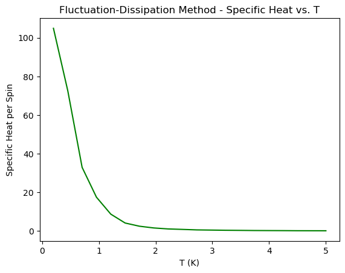

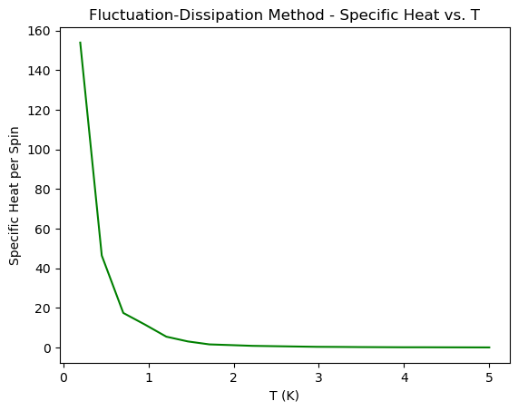

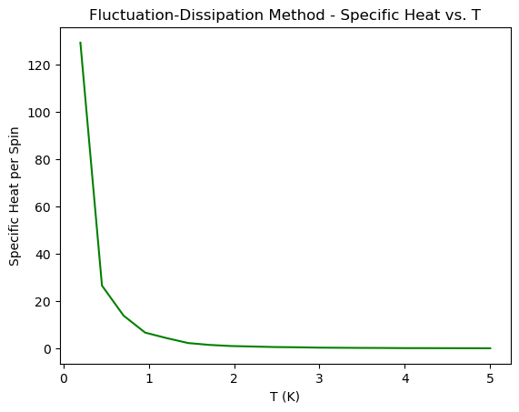

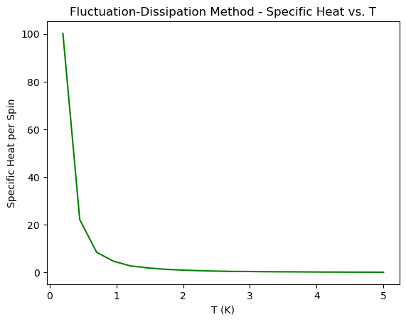

[figure not shown]

```python
%matplotlib inline
# plot the specific heat per spin for L = 5, 10, 20, 40
L = np.array([5, 10, 20, 40])

maxValues = []

for l in L:
    # make an l x l lattice for each L
    latticeStructure = PottsModel(N = l, J = 1)

    # Compute all of the parameters of the model given a temp range of 0.25 K to 5.0 K with 20 data points and 3000 Monte-Carlo time steps
    T, E, EVariance, M = latticeStructure.ParametersVsTemp(TMin = 0.2, TMax = 5.0, nPoints = 20, nIters = 3000)
    C = np.array([eV / t ** 2 for eV, t in zip(EVariance, T)])

    # get the max value from the specific heat array
    maxValues.append(np.max(C))

    plt.plot(T, C, 'g-')
    plt.title('Fluctuation-Dissipation Method - Specific Heat vs. T')
    plt.xlabel('T (K)')
    plt.ylabel('Specific Heat per Spin')
    plt.show()

## and finally, show the plot for maximum specific heat values per spin as a function of lattice size
#plt.xlabel('L value for L x L lattice')
#plt.ylabel('Maximum specific heat')
#plt.title('Fluctuation-Dissipation Method max Specific Heat vs L x L lattice size')
## compare the plot to the ln(L) as stated in the texbook by Giordano
#plt.plot(L, np.log(L))
#plt.plot(maxValues, L)
#plt.show()
```

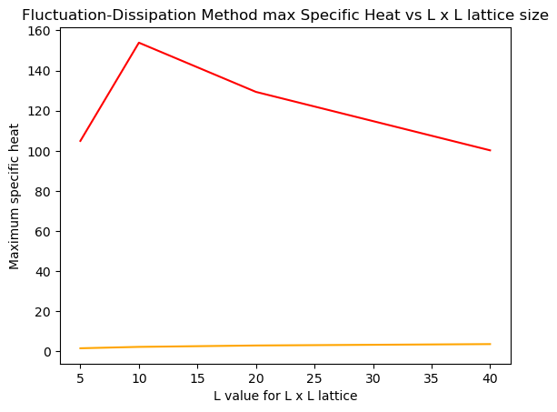

```python
# please ignore the last plot above, that cell took like 20 mins to run and I don't want to rerun it to omit the last plot. I had the x and y axes switched
# so here is my redo

# and finally, show the plot for maximum specific heat values per spin as a function of lattice size
plt.xlabel('L value for L x L lattice')
plt.ylabel('Maximum specific heat')
plt.title('Fluctuation-Dissipation Method max Specific Heat vs L x L lattice size')
# compare the plot to the ln(L) as stated in the texbook by Giordano
plt.plot(L, np.log(L), 'orange')
plt.plot(L, maxValues, 'red')
plt.show()
```

### Response to Question 3

All of these observations of the Potts Model help to support its validity in that it performs on a lattice structure in a very similar way to the Ising Model, which has proven to be successful in describing such phenomena like ferromagnetism. Introducing a third possibility for spin states allows another degree of freedom to the system, which in turn may lead to further success in describing these 'random' and non-linear interactions within large systems. In reality, spin states are never simply up or down, right or left, etc. there is a continuous path to which direction $L_z$, or $m_s$, may point in a quantum mechanical system. Hence introducing greater degrees of freedom helps to approach this more accurate model of the highly detailed, true universe.